# ship_study.csv

## cholesterol

| Feature | Result |
| --- | --- |
| Variable type | numeric |
| Number of missing obs. | 15 (0.7 %) |
| Number of unique values | 1668 |
| Median | 5.68 |
| 1st and 3rd quartiles | 4.92; 6.49 |
| Min. and max. | 2.67; 12.12 |

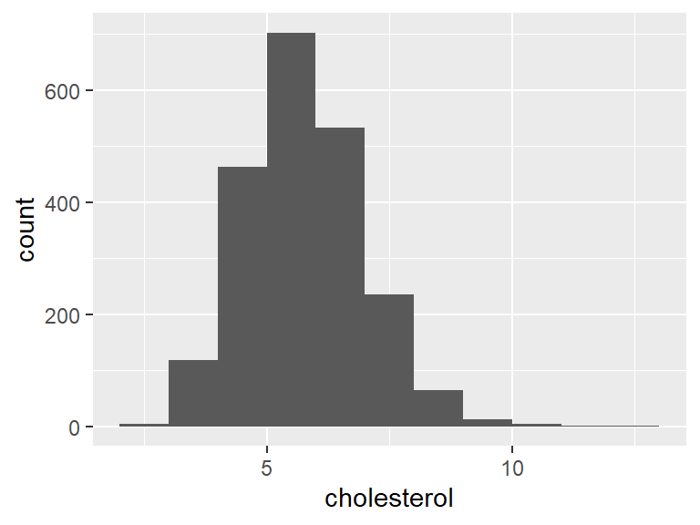

- Note that the following possible outlier values were detected: "2.67", "2.77", "2.9", "2.96", "9.3", "9.7", "9.87", "9.89", "9.9", "9.9", "10.05", "10.05", "10.11", "10.15", "10.75", "11.02", "12.12".

## hdl

| Feature | Result |
| --- | --- |
| Variable type | numeric |
| Number of missing obs. | 16 (0.74 %) |
| Number of unique values | 1111 |
| Median | 1.39 |
| 1st and 3rd quartiles | 1.14; 1.7 |
| Min. and max. | 0.42; 7.2 |

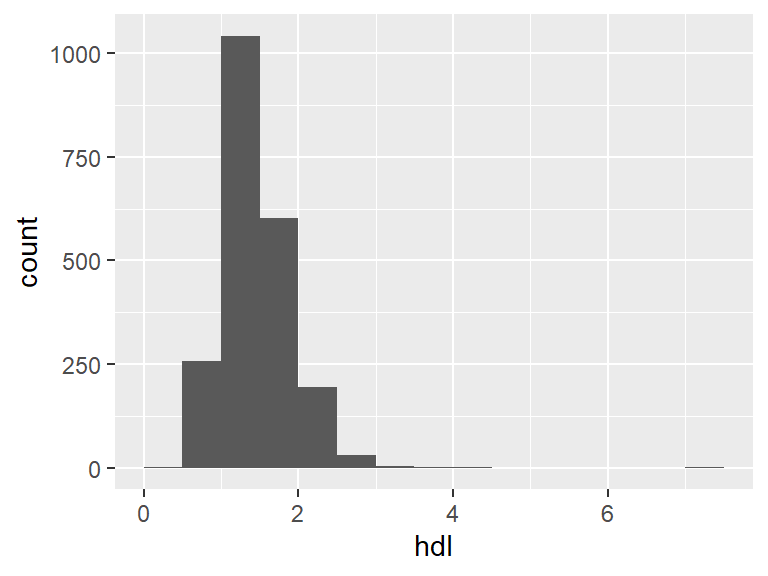

- Note that the following possible outlier values were detected: "0.42", "0.48", "0.5", "0.51", "0.64", "0.64", "0.64", "2.93", "2.95", "3", "3.06", "3.09", "3.14", "3.24", "3.51", "3.86", "4.39", "7.2".

## ldl

| Feature | Result |
| --- | --- |
| Variable type | numeric |
| Number of missing obs. | 28 (1.3 %) |
| Number of unique values | 2125 |
| Median | 3.52 |
| 1st and 3rd quartiles | 2.75; 4.24 |
| Min. and max. | 0.7; 9.24 |

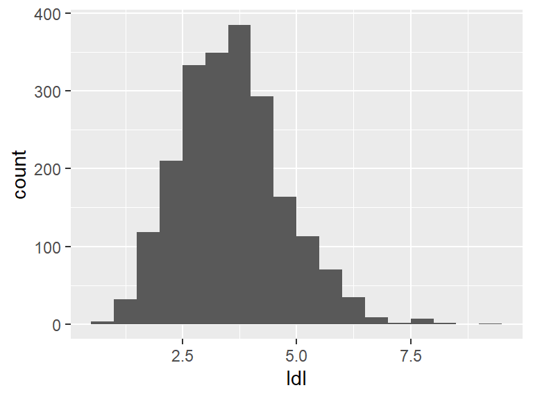

- Note that the following possible outlier values were detected: "6.69", "6.71", "6.76", "6.89", "6.95", "6.99", "7.25", "7.44", "7.5", "7.56", "7.59", "7.73", "7.79", "7.82", "7.93", "8.35", "8.46", "9.24".

## school

| Feature | Result |
| --- | --- |
| Variable type | integer |
| Number of missing obs. | 0 (0 %) |
| Number of unique values | 7 |
| Median | 2 |
| 1st and 3rd quartiles | 0; 2 |
| Min. and max. | 0; 99914 |

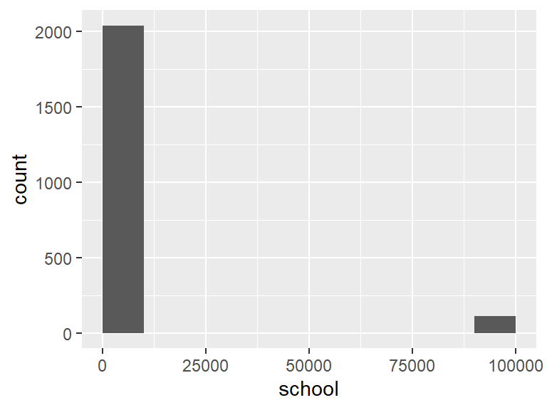

- Note that the following possible outlier values were detected: "3", "4", "99900", "99914".

## family

| Feature | Result |
| --- | --- |
| Variable type | integer |
| Number of missing obs. | 0 (0 %) |
| Number of unique values | 7 |
| Median | 1 |
| 1st and 3rd quartiles | 1; 3 |
| Min. and max. | 1; 99914 |

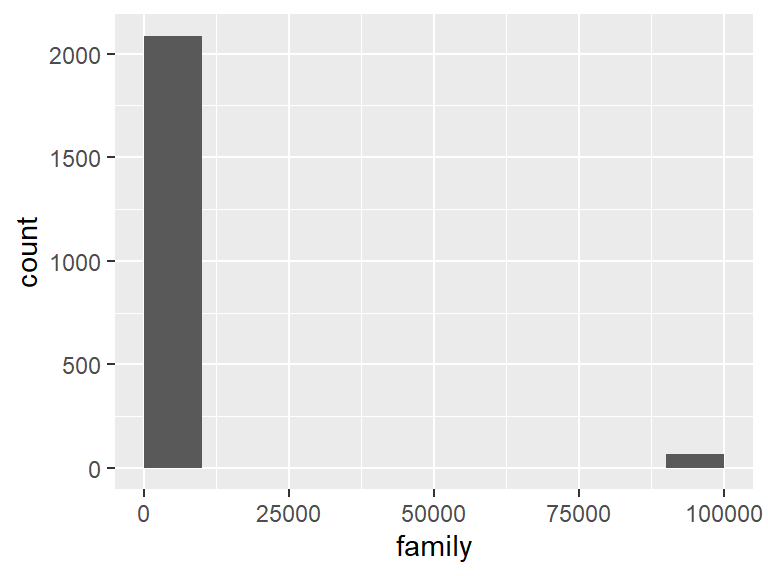

- Note that the following possible outlier values were detected: "99900", "99914".

## smoking

- Note that this variable is treated as a factor variable below, as it only takes a few unique values.

| Feature | Result |
| --- | --- |
| Variable type | integer |
| Number of missing obs. | 0 (0 %) |
| Number of unique values | 5 |
| Mode | “0” |
| Reference category | 0 |

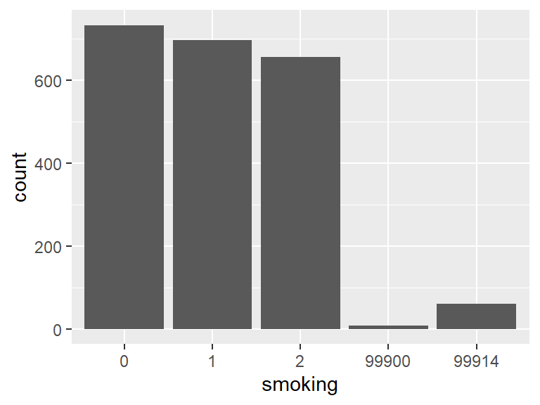

## myocard

- Note that this variable is treated as a factor variable below, as it only takes a few unique values.

| Feature | Result |
| --- | --- |
| Variable type | integer |
| Number of missing obs. | 0 (0 %) |
| Number of unique values | 5 |
| Mode | “2” |
| Reference category | 1 |

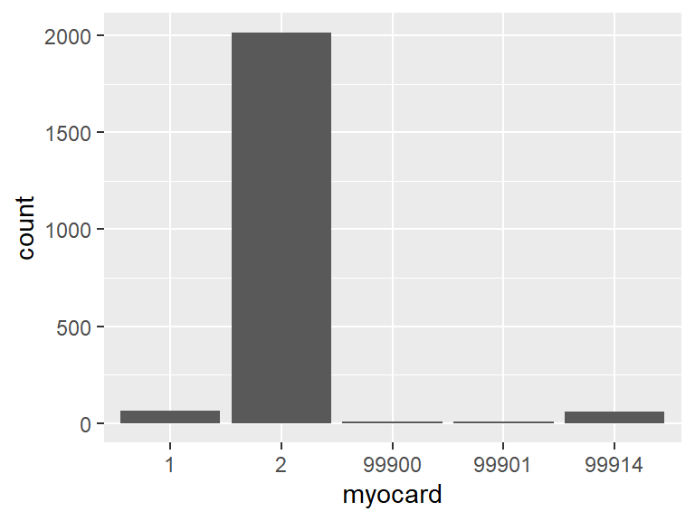

## stroke

- Note that this variable is treated as a factor variable below, as it only takes a few unique values.

| Feature | Result |
| --- | --- |
| Variable type | integer |
| Number of missing obs. | 0 (0 %) |
| Number of unique values | 5 |
| Mode | “2” |
| Reference category | 1 |

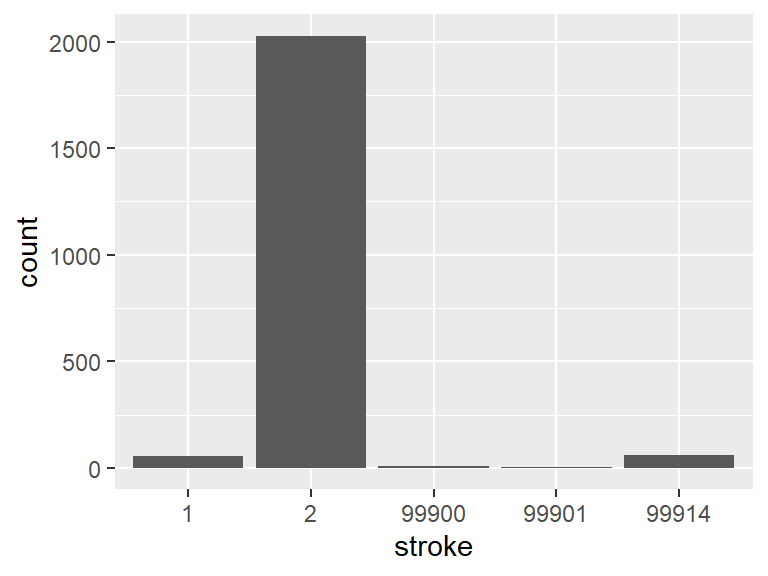

- Note that the following levels have at most five observations: "99901".

## diab_known

- Note that this variable is treated as a factor variable below, as it only takes a few unique values.

| Feature | Result |
| --- | --- |
| Variable type | integer |
| Number of missing obs. | 0 (0 %) |
| Number of unique values | 3 |
| Mode | “0” |
| Reference category | 0 |

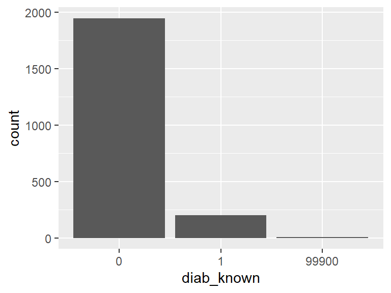

## diab_age

| Feature | Result |
| --- | --- |
| Variable type | integer |
| Number of missing obs. | 0 (0 %) |
| Number of unique values | 49 |
| Median | 99801 |
| 1st and 3rd quartiles | 99801; 99801 |
| Min. and max. | 12; 99900 |

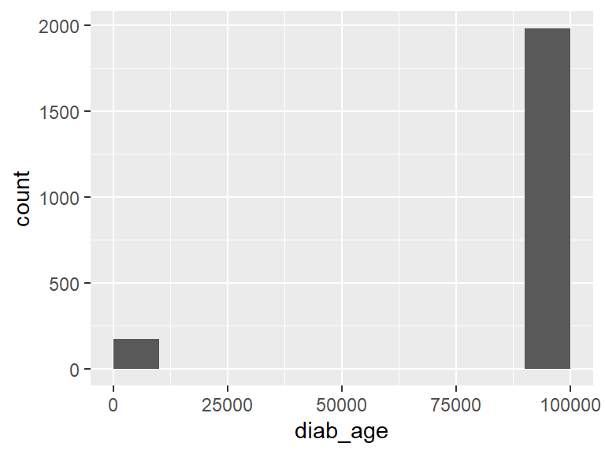

- Note that the following possible outlier values were detected: "12", "15", "18", "27", "29", "30", "33", "35", "36", "38", "40", "41", "42", "43", "44", "45", "46", "47", "48", "49", "50", "51", "52", "53", "54", "55", "56", "58", "59", "60", "61", "62", "63", "64", "65", "66", "67", "68", "69", "70", "71", "72", "73", "74", "75", "76", "79", "99900".

## contraception

- Note that this variable is treated as a factor variable below, as it only takes a few unique values.

| Feature | Result |
| --- | --- |
| Variable type | integer |
| Number of missing obs. | 0 (0 %) |
| Number of unique values | 4 |
| Mode | “99801” |
| Reference category | 1 |

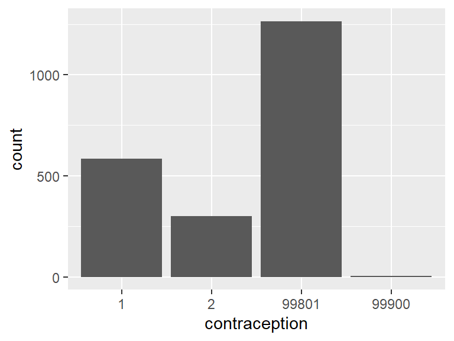

- Note that the following levels have at most five observations: "99900".

## income

- Note that this variable is treated as a factor variable below, as it only takes a few unique values.

| Feature | Result |
| --- | --- |
| Variable type | integer |
| Number of missing obs. | 0 (0 %) |
| Number of unique values | 5 |
| Mode | “2” |
| Reference category | 1 |

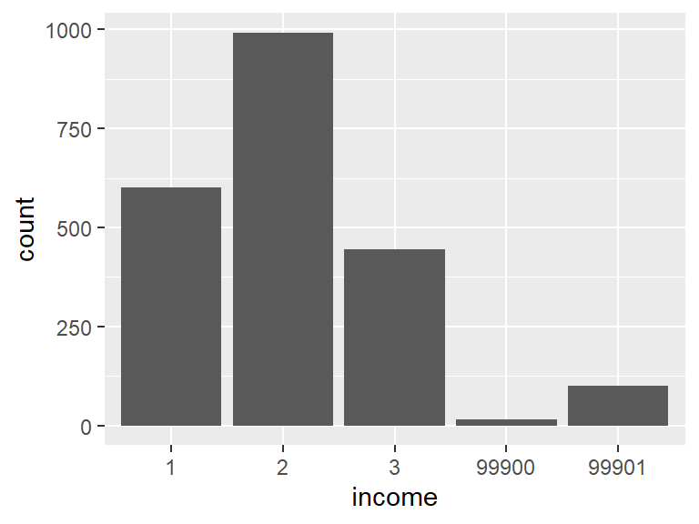

Report generation information:

- Created by: Could not determine from system (username: Unknown)
- Report creation time: Thu Oct 14 2021 10:56:26
- Report was run from directory: `C:/Users/marinoj/AppData/Local/Temp/RtmpwZh91A/shinyapp2a3458657ea3`
- dataMaid v1.4.1 [Pkg: 2021-10-08 from CRAN (R 4.1.1)]
- R version 4.1.1 (2021-08-10).
- Platform: x86_64-w64-mingw32/x64 (64-bit)(Windows 10 x64 (build 17763)).
- Function call: `makeDataReport(data = data, output = input$clean.output, ordering = input$clean.ordering, file = "dataMaid_report.rmd", replace = TRUE, openResult = FALSE, maxProbVals = as.numeric(input$clean.maxProbVals), reportTitle = dataFile$name, characterChecks = allChecks[unlist(checks.c)], factorChecks = allChecks[unlist(checks.f)], labelledChecks = allChecks[unlist(checks.l)], numericChecks = allChecks[unlist(checks.n)], integerChecks = allChecks[unlist(checks.i)], logicalChecks = allChecks[unlist(checks.b)], dateChecks = allChecks[unlist(checks.d)])`